# Previous hypertension diagnosis in Kenyan outpatient attenders

Dataset 4: Kenya hypertension screening survey

RSR feasibility analysis

2026-08-03

# Introduction

Roughly half of all hypertension in sub-Saharan Africa is undiagnosed, and the diagnosis step - not treatment or control - is where most of the care cascade is lost. This dataset is a cross-sectional screening survey of 1444 adults recruited at three types of Kenyan outpatient facility - a government (public) facility, a private facility and a faith-based mission facility - in which every participant had blood pressure measured three times and was asked whether they had ever previously been told by a health worker that they had hypertension.

That self-reported earlier diagnosis is a **different construct from the measured hypertension recorded on the same day**. Measured hypertension is physiology at one moment; a prior diagnosis is a record of having had contact with a health system that measured your blood pressure and told you the result. Modelling it asks who reaches diagnostic services, which is the more interesting question this file can answer and the one for which the predictor set below is assembled: age, sex, education, employment, body size, other diagnosed conditions and facility type.

**Aim.** Among these Kenyan outpatient attenders, we examined which of age band, sex, education, employment status, BMI category, self-reported diabetes, self-reported cardiovascular disease and facility type are independently associated with reporting a previous hypertension diagnosis, mutually adjusting for the others.

This is a *Purpose 3* analysis: several predictors are of interest and the question is which remain associated with the outcome after mutual adjustment.

# Methods

**Data source.** A cross-sectional facility-based screening survey of 1444 adults aged 18 and over attending outpatient services at three Kenyan facilities (450 public, 557 private, 437 faith-based).

**Variables.** The outcome is `prior_htn_diagnosis`, self-report of having previously been diagnosed with hypertension; the modelled event is **prior diagnosis = Yes** (412 of 1444, 28.5%). Predictors are age band (reference *26-35*); sex (reference *Female*); education (reference *No School*); employment status (reference *Employed / Self Employed*); WHO BMI category (reference *Healthy*); self-reported diabetes (reference *no*); self-reported cardiovascular disease (reference *no*); and facility type (reference *public*, the default point of care in Kenya). For diabetes and cardiovascular disease the *unknown* level is retained rather than treated as missing: “never tested / never told” is itself a state of contact with care and is precisely what this analysis is about.

**Measured `hypertension`, `systolic_bp` and `diastolic_bp` are excluded from the main model** and examined in a sensitivity analysis. They are not clean predictors of a prior diagnosis, because the relationship runs in both directions at once: a person is diagnosed *because* their pressure was high in the past, but a diagnosis leads to antihypertensive treatment, which *lowers* the pressure measured today. Today’s measurement is therefore partly a consequence of the outcome. **The file contains no medication variable of any kind**, so the two directions cannot be separated, and any coefficient for measured pressure in this model is uninterpretable as a causal quantity.

**BMI is categorical, not continuous.** Only the WHO `bmi_category` label is supplied, so no per-unit BMI odds ratio can be reported; and in fact **no predictor in this file is continuous** - age is banded too - so every estimate is a contrast between broad groups with certain residual confounding within band.

**Facility type and clustering.** `study_site` is a facility-*type* label (private, public, faith), not a facility identifier. It is a plausible confounder for a care-related outcome, since the three sectors serve different populations and have different case mixes, so it is included. But it is also the only handle on the fact that participants are clustered within three recruitment sites; with no facility ID, a random effect or cluster-robust standard errors are impossible, and the reported standard errors are almost certainly too small.

**Statistical analysis.** Logistic regression via `glm(family = binomial)`, justified because the outcome is binary; estimates are reported as odds ratios. We fitted a univariable model for each predictor first, then a single multivariable model containing all eight. Predictors were chosen in advance on subject-matter grounds, not by significance. Significance threshold 0.05; estimates are reported with 95% confidence intervals. Assumptions were checked with `performance::check_model()`. Analysis used R version 4.6.0 (2026-04-24) with tidyverse, gtsummary and performance.

**Missing data.** Complete-case analysis: 1370 of 1444 rows were analysed (74 dropped, 5.1%), containing 389 events. The outcome and four predictors are 100% complete; losses come from `bmi_category` (31 missing), `education` (21), `age_group` (17) and `employment` (6). `monthly_income`, missing for 453 participants (31.4%), is not in the main model despite being substantively relevant to an access-to-care question; the section *The cost of `monthly_income`* below reports exactly what including it would cost and gain.

# Results

## Sample characteristics

**Table 1. Sample characteristics by self-reported previous hypertension diagnosis.**

| **Characteristic** | **N** | **Overall** N = 1,370<sup>1</sup> | **No** N = 981<sup>1</sup> | **Yes** N = 389<sup>1</sup> |
| --- | --- | --- | --- | --- |
| Age band (years) | 1,370 |  |  |  |
| 26-35 |  | 286 (21%) | 264 (27%) | 22 (5.7%) |
| 18-25 |  | 100 (7.3%) | 96 (9.8%) | 4 (1.0%) |
| 36-45 |  | 272 (20%) | 226 (23%) | 46 (12%) |
| 46-55 |  | 256 (19%) | 172 (18%) | 84 (22%) |
| 56-65 |  | 240 (18%) | 119 (12%) | 121 (31%) |
| >65 |  | 216 (16%) | 104 (11%) | 112 (29%) |
| Sex | 1,370 |  |  |  |
| Female |  | 739 (54%) | 543 (55%) | 196 (50%) |
| Male |  | 631 (46%) | 438 (45%) | 193 (50%) |
| Education | 1,370 |  |  |  |
| No School |  | 177 (13%) | 126 (13%) | 51 (13%) |
| Primary |  | 234 (17%) | 151 (15%) | 83 (21%) |
| Secondary |  | 361 (26%) | 246 (25%) | 115 (30%) |
| Tertiary |  | 598 (44%) | 458 (47%) | 140 (36%) |
| Employment status | 1,370 |  |  |  |
| Employed / Self Employed |  | 894 (65%) | 678 (69%) | 216 (56%) |
| Unemployed |  | 311 (23%) | 230 (23%) | 81 (21%) |
| Retired |  | 165 (12%) | 73 (7.4%) | 92 (24%) |
| BMI category (WHO) | 1,370 |  |  |  |
| Healthy |  | 544 (40%) | 421 (43%) | 123 (32%) |
| Underweight |  | 80 (5.8%) | 74 (7.5%) | 6 (1.5%) |
| Overweight |  | 442 (32%) | 303 (31%) | 139 (36%) |
| Obese |  | 304 (22%) | 183 (19%) | 121 (31%) |
| Self-reported diabetes | 1,370 |  |  |  |
| no |  | 933 (68%) | 700 (71%) | 233 (60%) |
| yes |  | 187 (14%) | 85 (8.7%) | 102 (26%) |
| unknown |  | 250 (18%) | 196 (20%) | 54 (14%) |
| Self-reported cardiovascular disease | 1,370 |  |  |  |
| no |  | 885 (65%) | 716 (73%) | 169 (43%) |
| yes |  | 175 (13%) | 18 (1.8%) | 157 (40%) |
| unknown |  | 310 (23%) | 247 (25%) | 63 (16%) |
| Facility type | 1,370 |  |  |  |
| public |  | 442 (32%) | 333 (34%) | 109 (28%) |
| private |  | 509 (37%) | 381 (39%) | 128 (33%) |
| faith |  | 419 (31%) | 267 (27%) | 152 (39%) |

<sup>1</sup> n (%)

28.4% of the analytic sample (389 of 1370) reported a previous hypertension diagnosis. Those reporting one are much older (60% over 55 versus 23%), much more likely to report cardiovascular disease (40% versus 2%) or diabetes, more often retired, and heavier. Sex differences are slight.

## Exploratory figure

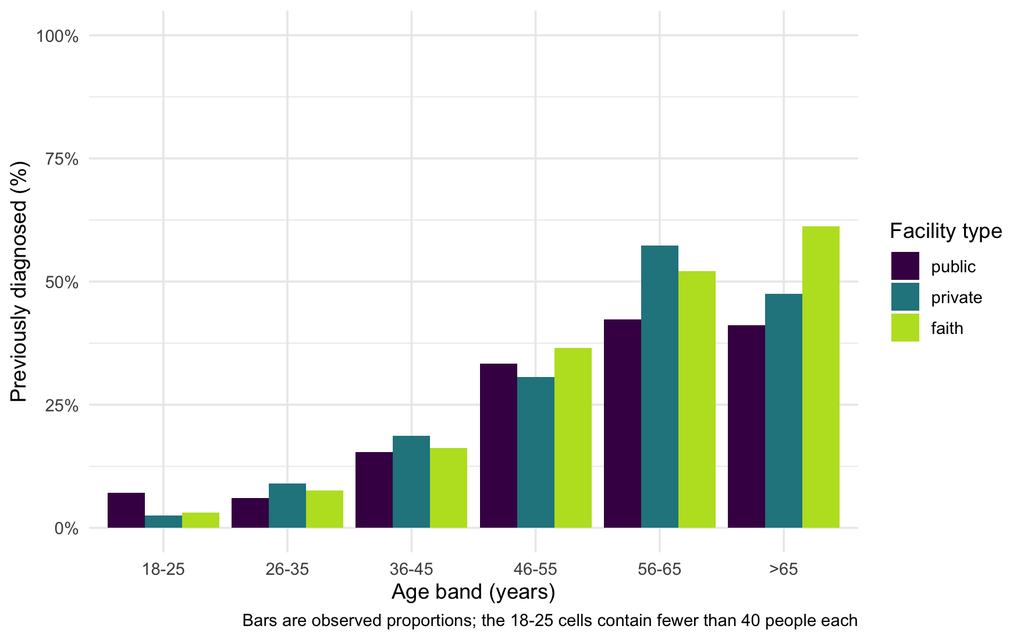

Figure 1. Proportion reporting a previous hypertension diagnosis, by age band and facility type.

## Univariable models

| **Characteristic** | **N** | **OR** | **95% CI** | **p-value** |
| --- | --- | --- | --- | --- |
| Age band (years) | 1,370 |  |  |  |
| 26-35 |  | — | — |  |
| 18-25 |  | 0.50 | 0.14, 1.35 | 0.2 |
| 36-45 |  | 2.44 | 1.44, 4.25 | 0.001 |
| 46-55 |  | 5.86 | 3.59, 9.94 | <0.001 |
| 56-65 |  | 12.2 | 7.51, 20.6 | <0.001 |
| >65 |  | 12.9 | 7.90, 22.0 | <0.001 |
| Sex | 1,370 |  |  |  |
| Female |  | — | — |  |
| Male |  | 1.22 | 0.96, 1.54 | 0.10 |
| Education | 1,370 |  |  |  |
| No School |  | — | — |  |
| Primary |  | 1.36 | 0.89, 2.08 | 0.2 |
| Secondary |  | 1.15 | 0.78, 1.72 | 0.5 |
| Tertiary |  | 0.76 | 0.52, 1.11 | 0.14 |
| Employment status | 1,370 |  |  |  |
| Employed / Self Employed |  | — | — |  |
| Unemployed |  | 1.11 | 0.82, 1.48 | 0.5 |
| Retired |  | 3.96 | 2.81, 5.59 | <0.001 |
| BMI category (WHO) | 1,370 |  |  |  |
| Healthy |  | — | — |  |
| Underweight |  | 0.28 | 0.11, 0.60 | 0.003 |
| Overweight |  | 1.57 | 1.18, 2.09 | 0.002 |
| Obese |  | 2.26 | 1.67, 3.07 | <0.001 |
| Self-reported diabetes | 1,370 |  |  |  |
| no |  | — | — |  |
| yes |  | 3.61 | 2.61, 4.99 | <0.001 |
| unknown |  | 0.83 | 0.59, 1.15 | 0.3 |
| Self-reported cardiovascular disease | 1,370 |  |  |  |
| no |  | — | — |  |
| yes |  | 37.0 | 22.6, 63.9 | <0.001 |
| unknown |  | 1.08 | 0.78, 1.49 | 0.6 |
| Facility type | 1,370 |  |  |  |
| public |  | — | — |  |
| private |  | 1.03 | 0.76, 1.38 | 0.9 |
| faith |  | 1.74 | 1.30, 2.34 | <0.001 |

Abbreviations: CI = Confidence Interval, OR = Odds Ratio

Crudely, the strongest associations are with other diagnosed conditions and with age. Self-reported cardiovascular disease carries OR 36.95 (95% CI 22.64 to 63.87) (p < 0.001) and self-reported diabetes OR 3.61 (95% CI 2.61 to 4.99) (p < 0.001). Relative to the 26-35 band, the odds of reporting a previous diagnosis are OR 5.86 (95% CI 3.59 to 9.94) at 46-55, OR 12.20 (95% CI 7.51 to 20.63) at 56-65 and OR 12.92 (95% CI 7.90 to 22.00) above 65. Retired participants have OR 3.96 (95% CI 2.81 to 5.59) relative to the employed (p < 0.001). Obesity carries OR 2.26 (95% CI 1.67 to 3.07) (p < 0.001) and underweight OR 0.28 (95% CI 0.11 to 0.60) (p = 0.003). Attenders at the faith-based facility have OR 1.74 (95% CI 1.30 to 2.34) the odds of those at the public facility (p < 0.001), while private-facility attenders are indistinguishable from public (OR 1.03 (95% CI 0.76 to 1.38), p = 0.863). Neither sex (OR 1.22 (95% CI 0.96 to 1.54), p = 0.097) nor education (tertiary OR 0.76 (95% CI 0.52 to 1.11), p = 0.144) shows a crude association.

## Why adjustment is needed

The crude odds ratios are badly confounded because the predictors are strongly interlocked. **Age band** is the central problem. It is the strongest determinant of ever having been diagnosed - simply because older people have had more years and more clinical encounters in which a blood pressure could be taken - and it is associated with almost every other predictor here. Retirement is nearly a deterministic function of age (92% of retired participants are over 55), so the crude retirement OR of 3.96 is largely an age effect wearing a different label. Education is steeply age-patterned in the opposite direction: 16% of the over-65s have tertiary education against 64% of the 26-35 band, so the crude education contrasts are the *youth* of the educated cancelling out any access advantage they may have, and only adjustment for age can separate the two. **Facility type** is the second key confounder, and the reason it must be in the model: the three sectors serve very different populations. The faith-based facility’s attenders are older and far more likely to report cardiovascular disease (24% versus 8% at the public facility), so its crude excess of previously diagnosed attenders may be case mix rather than anything about the facility. **Comorbidity** (diabetes, cardiovascular disease) confounds the socio-economic contrasts in turn, because people already in chronic-disease care get their blood pressure taken repeatedly, and comorbidity is unevenly distributed across age, body size and facility. Mutual adjustment lets each odds ratio be read as a comparison between attenders alike on the other seven measured characteristics.

## Multivariable model

| **Characteristic** | **OR** | **95% CI** | **p-value** |
| --- | --- | --- | --- |
| Age band (years) |  |  |  |
| 26-35 | — | — |  |
| 18-25 | 0.59 | 0.15, 1.83 | 0.4 |
| 36-45 | 1.94 | 1.07, 3.58 | 0.031 |
| 46-55 | 3.85 | 2.20, 6.97 | <0.001 |
| 56-65 | 8.17 | 4.58, 15.1 | <0.001 |
| >65 | 9.53 | 4.94, 19.0 | <0.001 |
| Sex |  |  |  |
| Female | — | — |  |
| Male | 1.01 | 0.73, 1.40 | >0.9 |
| Education |  |  |  |
| No School | — | — |  |
| Primary | 2.66 | 1.39, 5.20 | 0.004 |
| Secondary | 2.84 | 1.47, 5.60 | 0.002 |
| Tertiary | 2.57 | 1.27, 5.29 | 0.010 |
| Employment status |  |  |  |
| Employed / Self Employed | — | — |  |
| Unemployed | 0.89 | 0.56, 1.42 | 0.6 |
| Retired | 1.13 | 0.68, 1.85 | 0.6 |
| BMI category (WHO) |  |  |  |
| Healthy | — | — |  |
| Underweight | 0.62 | 0.22, 1.48 | 0.3 |
| Overweight | 1.86 | 1.28, 2.74 | 0.001 |
| Obese | 2.95 | 1.96, 4.47 | <0.001 |
| Self-reported diabetes |  |  |  |
| no | — | — |  |
| yes | 1.83 | 1.20, 2.79 | 0.005 |
| unknown | 0.79 | 0.44, 1.45 | 0.5 |
| Self-reported cardiovascular disease |  |  |  |
| no | — | — |  |
| yes | 44.3 | 24.5, 84.9 | <0.001 |
| unknown | 1.56 | 0.94, 2.57 | 0.083 |
| Facility type |  |  |  |
| public | — | — |  |
| private | 0.85 | 0.54, 1.33 | 0.5 |
| faith | 0.54 | 0.35, 0.84 | 0.006 |

Abbreviations: CI = Confidence Interval, OR = Odds Ratio

**Model fit: multivariable logistic model for previous hypertension diagnosis**

[output not shown]

Conditional on the other seven predictors, age remains dominant: OR 3.85 (95% CI 2.20 to 6.97) at 46-55, OR 8.17 (95% CI 4.58 to 15.11) at 56-65 and OR 9.53 (95% CI 4.94 to 18.96) above 65, all relative to the 26-35 band. Self-reported cardiovascular disease carries an extreme OR 44.35 (95% CI 24.46 to 84.90) (p < 0.001) - see the caution below - and diabetes OR 1.83 (95% CI 1.20 to 2.79) (p = 0.005). Obesity retains OR 2.95 (95% CI 1.96 to 4.47) (p < 0.001) and being overweight OR 1.86 (95% CI 1.28 to 2.74) (p = 0.001). Education becomes strongly and positively associated once age is held constant: relative to no schooling, primary OR 2.66 (95% CI 1.39 to 5.20), secondary OR 2.84 (95% CI 1.47 to 5.60) and tertiary OR 2.57 (95% CI 1.27 to 5.29) (all p < 0.05). Attenders at the faith-based facility have OR 0.54 (95% CI 0.35 to 0.84) the adjusted odds of public-facility attenders (p = 0.006) - the reverse of the crude direction. Employment and sex are null after adjustment. These are associations among the attenders observed, not effects of intervening on any of these variables.

**Caution on the cardiovascular-disease coefficient.** An odds ratio of 44 is not a plausible causal quantity and rests on a thin cell: only 18 of the 175 participants reporting cardiovascular disease do *not* also report a hypertension diagnosis. This is close to - though not actually - quasi-complete separation, which is why the confidence interval is so wide. Substantively, cardiovascular disease is not a clean upstream exposure: it is largely diagnosed in the same clinical encounters that diagnose hypertension, and it is often a consequence of hypertension, so this coefficient reflects co-detection and shared care contact at least as much as any effect of one condition on the other. It is retained because leaving it out changes conclusions about facility type (see the sensitivity analysis), but it should be described as a marker of engagement with chronic-disease care and never as a risk factor.

## The cost of `monthly_income`

**Table 2. What adding `monthly_income` costs.**

`monthly_income` is missing for 31% of participants; listwise deletion removes them from the whole model, not just from that one coefficient. AICs from different samples are not comparable.

| Model | N | % of file | Events | Parameters | Events/parameter | AIC |
| --- | --- | --- | --- | --- | --- | --- |
| Main model (no income) | 1370 | 94.9 | 389 | 20 | 19.4 | 1118.5 |
| Same model, income complete-cases only | 964 | 66.8 | 284 | 20 | 14.2 | 786.9 |
| Model with monthly_income added | 964 | 66.8 | 284 | 24 | 11.8 | 786.5 |

This is the most important methodological point in this dataset, and it bites hardest here because household income is genuinely relevant to an access-to-care outcome - this is the one model where a student has a real reason to want the variable. `monthly_income` is missing for 31.4% of participants, and because `glm()` deletes rows listwise, adding it removes those participants from *every* coefficient in the model, not just from the income coefficient. The complete-case N falls from **1370** to **964** (67% of the file) and events from **389** to **284**: 406 participants and 105 events discarded to buy 4 extra parameters, cutting events per parameter from 19.4 to 11.8. The likelihood-ratio test comparing the two models on the *same* 964 rows gives p = 0.080, so even on its own restricted sample income does not improve the model at the 0.05 level, although it comes closer here than in any other outcome in this dataset.

The missingness is emphatically not random, and in a way that is fatal for this particular research question. Non-response to the income question ranges from 18% at the faith-based facility to 48% at the private facility, and rises with education (from 22% among those with no schooling to 40% among the tertiary educated). In other words, the propensity to withhold income is itself patterned by two of the model’s own predictors - facility type and education - so restricting to income responders systematically reshapes exactly the contrasts this analysis is about. The effect is visible: the faith-facility odds ratio moves from 0.54 to 0.52, tertiary education from 2.57 to 3.00, and the cardiovascular-disease coefficient from 44.3 to 52.6. **The main model therefore excludes `monthly_income`**, and a student who wants an income gradient for this outcome must use multiple imputation rather than complete cases; taking the reduced sample at face value would be a mistake.

## Unadjusted versus adjusted

**Table 3. Unadjusted and adjusted odds ratios.**

| **Characteristic** | **Unadjusted** **N** | **Unadjusted** **OR** | **Unadjusted** **95% CI** | **Unadjusted** **p-value** | **Adjusted** **OR** | **Adjusted** **95% CI** | **Adjusted** **p-value** |
| --- | --- | --- | --- | --- | --- | --- | --- |
| Age band (years) | 1,370 |  |  |  |  |  |  |
| 26-35 |  | — | — |  | — | — |  |
| 18-25 |  | 0.50 | 0.14, 1.35 | 0.2 | 0.59 | 0.15, 1.83 | 0.4 |
| 36-45 |  | 2.44 | 1.44, 4.25 | 0.001 | 1.94 | 1.07, 3.58 | 0.031 |
| 46-55 |  | 5.86 | 3.59, 9.94 | <0.001 | 3.85 | 2.20, 6.97 | <0.001 |
| 56-65 |  | 12.2 | 7.51, 20.6 | <0.001 | 8.17 | 4.58, 15.1 | <0.001 |
| >65 |  | 12.9 | 7.90, 22.0 | <0.001 | 9.53 | 4.94, 19.0 | <0.001 |
| Sex | 1,370 |  |  |  |  |  |  |
| Female |  | — | — |  | — | — |  |
| Male |  | 1.22 | 0.96, 1.54 | 0.10 | 1.01 | 0.73, 1.40 | >0.9 |
| Education | 1,370 |  |  |  |  |  |  |
| No School |  | — | — |  | — | — |  |
| Primary |  | 1.36 | 0.89, 2.08 | 0.2 | 2.66 | 1.39, 5.20 | 0.004 |
| Secondary |  | 1.15 | 0.78, 1.72 | 0.5 | 2.84 | 1.47, 5.60 | 0.002 |
| Tertiary |  | 0.76 | 0.52, 1.11 | 0.14 | 2.57 | 1.27, 5.29 | 0.010 |
| Employment status | 1,370 |  |  |  |  |  |  |
| Employed / Self Employed |  | — | — |  | — | — |  |
| Unemployed |  | 1.11 | 0.82, 1.48 | 0.5 | 0.89 | 0.56, 1.42 | 0.6 |
| Retired |  | 3.96 | 2.81, 5.59 | <0.001 | 1.13 | 0.68, 1.85 | 0.6 |
| BMI category (WHO) | 1,370 |  |  |  |  |  |  |
| Healthy |  | — | — |  | — | — |  |
| Underweight |  | 0.28 | 0.11, 0.60 | 0.003 | 0.62 | 0.22, 1.48 | 0.3 |
| Overweight |  | 1.57 | 1.18, 2.09 | 0.002 | 1.86 | 1.28, 2.74 | 0.001 |
| Obese |  | 2.26 | 1.67, 3.07 | <0.001 | 2.95 | 1.96, 4.47 | <0.001 |
| Self-reported diabetes | 1,370 |  |  |  |  |  |  |
| no |  | — | — |  | — | — |  |
| yes |  | 3.61 | 2.61, 4.99 | <0.001 | 1.83 | 1.20, 2.79 | 0.005 |
| unknown |  | 0.83 | 0.59, 1.15 | 0.3 | 0.79 | 0.44, 1.45 | 0.5 |
| Self-reported cardiovascular disease | 1,370 |  |  |  |  |  |  |
| no |  | — | — |  | — | — |  |
| yes |  | 37.0 | 22.6, 63.9 | <0.001 | 44.3 | 24.5, 84.9 | <0.001 |
| unknown |  | 1.08 | 0.78, 1.49 | 0.6 | 1.56 | 0.94, 2.57 | 0.083 |
| Facility type | 1,370 |  |  |  |  |  |  |
| public |  | — | — |  | — | — |  |
| private |  | 1.03 | 0.76, 1.38 | 0.9 | 0.85 | 0.54, 1.33 | 0.5 |
| faith |  | 1.74 | 1.30, 2.34 | <0.001 | 0.54 | 0.35, 0.84 | 0.006 |

Abbreviations: CI = Confidence Interval, OR = Odds Ratio

## Diagnostics

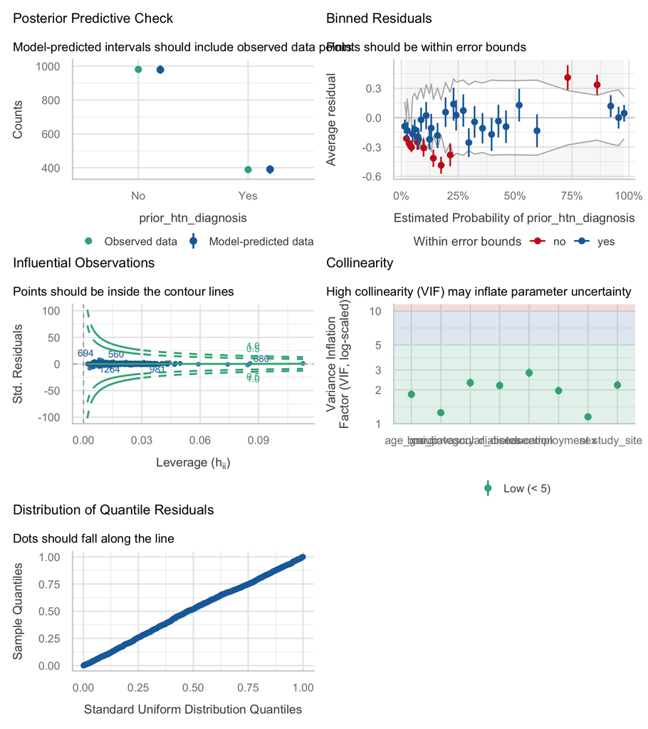

For a logistic model only some `check_model()` panels apply. **Binned residuals**: 70.3% of bins fall inside the error bounds against a rule-of-thumb target of about 95%, so there is genuine lack of fit. As with the other outcomes in this file the cause is structural - every predictor is a coarse category, so only a limited number of distinct fitted probabilities can be produced - and it cannot be repaired without continuous age and BMI. **Collinearity** is low (maximum VIF 2.83, for education), which matters a great deal here: it means the education and facility-type reversals in Table 3 are real confounding and not artefacts of unstable estimation. **Separation** is the live risk in this model: the cardiovascular-disease contrast rests on a cell of just 18 participants (CVD reported, no prior hypertension diagnosis), which is why its odds ratio is enormous and its confidence interval spans a factor of 3. The model converges and no coefficient runs away to infinity, so this is sparse-data bias rather than true separation, but the coefficient should be reported with the caveat above and never interpreted as a magnitude. **Influential observations**: no point exceeds the Cook’s distance contours. **Events per parameter** is 19.4, adequate. Homogeneity of variance and normality of residuals are printed for completeness but do not apply to a binomial GLM.

## Sensitivity analyses

**Dropping cardiovascular disease.** Because that coefficient is so extreme, the model was refitted without it on the same 1370 rows. The facility result does not survive: the faith-facility odds ratio moves from OR 0.54 (95% CI 0.35 to 0.84) back to OR 1.18 (95% CI 0.82 to 1.69, p = 0.377), i.e. no difference from the public facility at all. The education gradient also weakens sharply (tertiary OR 1.32 (95% CI 0.74 to 2.38, p = 0.353)). In other words, **the two headline findings of this analysis exist only conditional on cardiovascular disease status**, a variable that is arguably a consequence of the same care contact that produces the outcome. Adjusting for it may be removing confounding by case mix, or may be conditioning on a collider and manufacturing associations that do not exist. This file cannot distinguish the two, and a student report should present both models rather than choosing.

**Table 4. Measured hypertension against self-reported prior diagnosis.**

| Measured hypertension | Prior diagnosis: No | Prior diagnosis: Yes |
| --- | --- | --- |
| No | 826 | 193 |
| Yes | 206 | 219 |

**Adding today’s measured hypertension.** The two variables agree on only 72% of participants: just 52% of those hypertensive on measurement report a prior diagnosis, and 193 of the 412 who report a prior diagnosis are normotensive today. Adding `hypertension` to the model gives OR 3.01 (95% CI 2.17 to 4.19), p < 0.001, and lowers AIC from 1118.5 to 1077.0. **This must not be read as an effect of blood pressure on diagnosis.** Reverse causation is guaranteed here and runs in both directions: a diagnosis is given because pressure was high in the *past*, which inflates the association; and the diagnosis brings antihypertensive treatment which lowers the pressure measured *today*, which deflates it. The file records **no medication whatsoever**, so the two cannot be untangled, and the observed OR of 3.0 is a net of the two opposing mechanisms with no way to recover either. That the OR is only about 3 - rather than the very large value one would expect if diagnosis simply tracked pressure - is itself informative: it is consistent with substantial treatment effect among the diagnosed, but it is equally consistent with poor recall or with single-visit measurement error, and these data cannot choose between those explanations.

# Discussion

Among these Kenyan outpatient attenders, having ever been told you have hypertension is driven by age, by body size, by other diagnosed chronic conditions and - once age is held constant - by education. The educational gradient is the substantive finding and it is invisible in the crude analysis: tertiary-educated attenders have OR 2.57 (95% CI 1.27 to 5.29) the odds of attenders who never went to school, of the same age, sex, employment status, body size, comorbidity and facility type, whereas crudely they appear marginally *less* likely to have been diagnosed. The reason is that education in Kenya is heavily age-patterned, so the crude comparison is mostly a comparison of young with old. Practically, this points to schooling - a proxy for health literacy and for the ability to seek and use services - as an axis of inequality in diagnosis, not merely in treatment. The awareness gap is the other headline: only 52% of participants who were hypertensive at this visit had ever been told so.

**Limitations.** The outcome is **self-reported** and depends on recall and on having understood what a clinician said; misclassification is certain and is probably differential by education, which is the very predictor of interest - better-educated participants may be better at recalling and reporting a diagnosis, so part of the education gradient reported here may be reporting behaviour rather than access. This is a **facility-based convenience sample**, so it describes attenders at three specific facilities and nothing wider; by construction everyone in it is already in contact with a health facility today, which truncates the access spectrum this analysis is meant to describe. The design is **cross-sectional**: comorbidity, body size and facility attendance are all recorded at the same visit as the outcome, so temporal ordering is assumed, not observed. The **cardiovascular-disease coefficient is uninterpretable as a magnitude** and, as the sensitivity analysis shows, both headline findings depend on adjusting for it; if it is a collider rather than a confounder, those findings are artefacts. **No medication variable exists**, which is a serious gap for any analysis linking diagnosis to measured pressure. **No facility identifier exists** either, only the three-level facility type, so clustering of attenders within facilities cannot be modelled and the standard errors are too small. **`monthly_income` was excluded** because including it would cost 406 rows and 105 events, so household economic position - arguably the most important determinant of access to diagnosis - is simply unadjusted for, and its missingness is itself patterned by facility and education. **No predictor is continuous**, so age and adiposity effects are cell contrasts with residual confounding within band. Insurance status, distance to facility, and the reason for today’s visit are all absent, and all three would plausibly dominate an access analysis.

**Future work.** Repeat with insurance status, distance to facility and reason for attendance, a facility identifier for clustering, medication use, and multiple imputation for income - none of which this extract carries.

# Feasibility notes

*NOT part of a student report.*

- **The most interesting outcome in this dataset, and the most fragile.** It is about access to and contact with care rather than physiology, it is fully observed (0 missing), it has 389 events in 1370 complete cases and 19.4 events per parameter, and it produces the most striking crude-versus-adjusted table in the catalogue - two clean sign reversals (facility type OR 1.74 (95% CI 1.30 to 2.34) to OR 0.54 (95% CI 0.35 to 0.84); tertiary education OR 0.76 (95% CI 0.52 to 1.11) to OR 2.57 (95% CI 1.27 to 5.29)) with maximum VIF only 2.83, so they are real confounding.
- **MAJOR problem: both headline results depend on `cardiovascular_disease`.** Drop it and the faith-facility effect becomes OR 1.18 (95% CI 0.82 to 1.69, p = 0.377) and tertiary education OR 1.32 (95% CI 0.74 to 2.38, p = 0.353) - both null. CVD is plausibly a collider (diagnosed in the same care contact as hypertension) rather than a confounder, so the analysis may be manufacturing its own findings. A student must be told to fit both models. This is the biggest threat to the outcome.
- **Near-sparse cell driving an OR of 44.** Only 18 of 175 participants reporting cardiovascular disease do not also report a hypertension diagnosis. Not formal separation - the model converges - but the CI spans a factor of 3 and the magnitude is meaningless.
- **Trap: measured `hypertension` / `systolic_bp` / `diastolic_bp` as predictors.** Not forbidden the way they are for the `hypertension` outcome - they are genuinely different constructs, agreeing on only 72% of rows - but the relationship is bidirectional (diagnosis follows past high pressure; treatment lowers present pressure) and there is **no medication variable** to break the loop. Students will report the OR 3.01 as “high blood pressure causes diagnosis” unless explicitly warned.
- **THE missing-data teaching case, and it is worst here.** `monthly_income` is 31.4% missing; including it drops N from 1370 to 964 (67% of the file) and events from 389 to 284 (LRT p = 0.080). Unlike the other three outcomes, income is *substantively central* to this research question, so the student genuinely wants it - and its missingness is patterned by facility (48% private vs 18% faith) and by education, i.e. by two of the model’s own predictors. Best missing-data discussion in the catalogue; multiple imputation is the only honest route.
- **`study_site` is a facility *type*, not a facility ID.** Three sites, no identifier, so clustering cannot be modelled at all and standard errors are optimistic. It doubles as both a substantive predictor and the only (crude) handle on clustering, which students should be told is unsatisfactory.
- **Self-report outcome with differential misclassification by education** - the same variable the analysis reports as its main finding. Must be discussed, not hidden.
- **Binned residuals fail (70.3% of bins inside bounds)**, for the same structural reason as the other outcomes: no continuous predictors exist in this file, so only a handful of fitted probabilities are possible. Not repairable here.
- **`employment` is nearly collinear with age in substance if not in VIF** (92% of retired participants are over 55); its crude OR of 3.96 collapsing to 1.13 is a good teaching example but will confuse students who chose it as an exposure.
- **`current_smoker` was left out** of this model deliberately: only 93 smokers in the file, no substantive reason to expect it to predict *diagnosis*, and the events-per-parameter budget is better spent elsewhere.